# From Admissible Perturbation to Perturbation Interval

# Benchmark simulation: stigma, shelter use, and prioritization

This R Markdown file reproduces the simulation in Section IV-C of the paper Technical Veracity is Not Representational Veracity: Community-Grounded Perturbation for Benchmarking Human-Systems Data. It generates two-period data from the DAG in Figure 1 using logistic equations for latent housing need ($Y_1$, $Y_2$) and a binomial model for shelter nights ($X_1$). The algorithm is a fixed rule, score = $X_1$, and the top 20% of scores are placed. No model is trained, and $Y_2$ is used only to evaluate who is placed.

The code applies two perturbations: more cold nights ($c$, the admissible perturbation, which changes shelter use but not need) and random noise ($q$,the share of shelter counts replaced with another person’s). It reports recall among people who truly need housing, for stigmatized and non-stigmatized people,and the gap between them, across each perturbation interval. It produces output presented in Table I. All parameters are invented for illustration, and results use seed 1111 with $n = 50{,}000$.

## 1. The DAG assuming two periods and a score to prioritize shelter use in period 2 based on period 1 shelter use

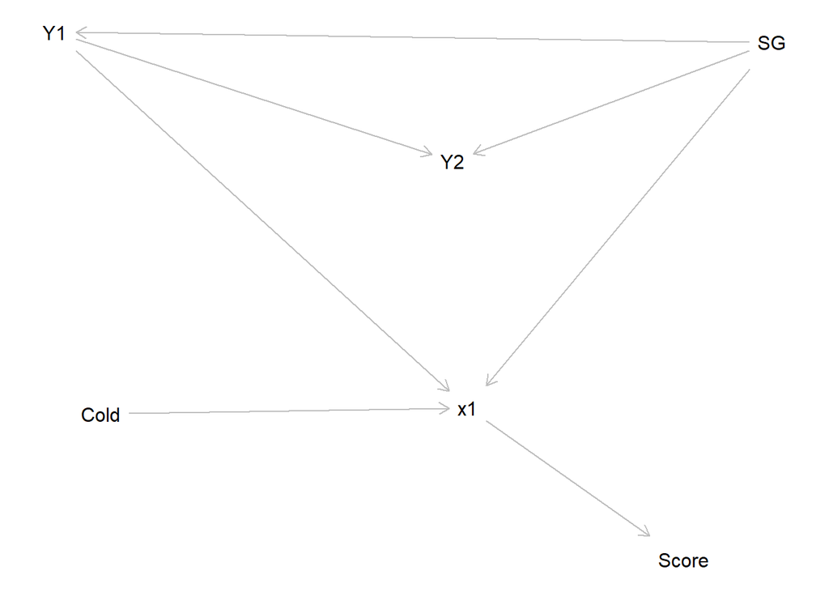

```r
# SG = stigmatized identity; Y1, Y2 = (latent) housing need in periods 1 and 2
# x1 = shelter nights in period 1; Cold = share of cold nights in period 1
# Score = algorithm's priority score (uses x1 only)
dag <- dagitty('dag {
bb="-2.37,-4.697,3.894,4.778"
Cold [pos="0.621,1.158"]
SG [pos="2.403,-2.185"]
Score [pos="2.169,2.469"]
Y1 [latent,pos="0.500,-2.277"]
Y2 [latent,pos="1.556,-1.114"]
x1 [pos="1.596,1.103"]
Cold -> x1
SG -> Y1
SG -> Y2
SG -> x1
Y1 -> Y2
Y1 -> x1
x1 -> Score
}
')
plot(dag)
```

```r
#
# # Admissibility: cold does not change need
# dseparated(dag, "Cold", "Y2", list())            # TRUE
# dseparated(dag, "Cold", "Y2", c("Y1", "SG"))     # TRUE
# # But the algorithm's score does depend on cold, through x1
# dseparated(dag, "Cold", "Score", list())         # FALSE
# # x1 is a collider: conditioning on it links need and cold
# dseparated(dag, "Cold", "Y2", "x1")              # FALSE
```

## 2. Parameters for functional forms to generate data.

Artificially set for simulation. We assume 30 days per period.

```r
pars <- list(
  p_sg     = 0.20,                                   # share stigmatized
  n_nights = 30,                                     # nights observed per period
  y1       = c(b0 = -1.6, sg = 0.6),                 # housing need in period 1
  y2       = c(b0 = -2.4, lag = 2.5, sg = 0.6),      # housing need in period 2
  shelter  = c(b0 = -3, need = 3, cold = 3, stigma = 2.5)
)
cold_base <- 0.05    # 5% of nights are cold in a normal period
```

## 3. Simulate people and shelter use based on DAG and functional forms

```r
# Step A: need in both periods. This simple example assumes need is independent from weather.

simulate_people <- function(n) {
  SG   <- rbinom(n, 1, pars$p_sg)
  p_y1 <- plogis(pars$y1[["b0"]] + pars$y1[["sg"]] * SG)
  Y1   <- rbinom(n, 1, p_y1)
  p_y2 <- plogis(pars$y2[["b0"]] + pars$y2[["lag"]] * Y1 + pars$y2[["sg"]] * SG)
  Y2   <- rbinom(n, 1, p_y2)
  # u: one fixed uniform number per person, reused across weather scenarios
  tibble(SG, Y1, p_y2, Y2, u = runif(n))
}

# Step B: Count of shelter nights in period 1, given need, stigma and cold.
# qbinom(u, ...) is a binomial draw that reuses the same u across scenarios, so the same people can be compared under different weather.
add_shelter <- function(people, cold) {
  s   <- pars$shelter
  eta <- s[["b0"]] + people$Y1 * (s[["need"]] + s[["cold"]] * cold - s[["stigma"]] * people$SG)
  people$x1 <- qbinom(people$u, size = pars$n_nights, prob = plogis(eta))
  people
}

# Step C: the NAIVE (standard) perturbation. A share q of people get another random person's shelter count. It ignores SG, need and weather.
add_noise <- function(d, q) {
  swap <- runif(nrow(d)) < q
  d$x1[swap] <- sample(d$x1)[swap]
  d
}

# Look at the DGP: average shelter nights by need and SG, normal weather
add_shelter(simulate_people(10000), cold_base) %>%
  group_by(Y1, SG) %>%
  summarise(mean_nights = mean(x1), .groups = "drop")
```

```
## # A tibble: 4 × 3
##      Y1    SG mean_nights
##   <int> <int>       <dbl>
## 1     0     0        1.41
## 2     0     1        1.46
## 3     1     0       16.1
## 4     1     1        2.57
```

## 4. Metrics

```r
# Expected top-k placement.
# Tied people at the cutoff share the remaining slots fractionally to removes random tie-breaking noise.
expected_placed <- function(score, k = 0.20) {
  m     <- ceiling(k * length(score))
  cut   <- sort(score, decreasing = TRUE)[m]
  above <- sum(score > cut)
  tied  <- sum(score == cut)
  ifelse(score > cut, 1, ifelse(score == cut, (m - above) / tied, 0))
}

evaluate <- function(d, score, k = 0.20) {
  w    <- expected_placed(score, k)
  need <- d$Y2 == 1
  tibble(
    recall_stigmatized       = mean(w[need & d$SG == 1]),  # stigmatized in need who are placed
    recall_non         = mean(w[need & d$SG == 0]),
    gap                = recall_stigmatized - recall_non,
    share_stigmatized_placed = sum(w[d$SG == 1]) / sum(w), # stigmatized share of the top 20%
    share_stigmatized_need   = mean(d$SG[need])            # stigmatized share of true need
  )
}
```

# 4. A simulated data check

```r
# Check People
set.seed(1111)
people <- simulate_people(1000)

# The same people under normal weather and under more cold nights
d_normal <- add_shelter(people, cold_base)   # 5% cold nights
d_cold   <- add_shelter(people, 0.50)        # 50% cold nights

side_by_side <- people %>%
  mutate(id = row_number(),
         x1_normal = d_normal$x1,
         x1_cold   = d_cold$x1) %>%
  select(id, SG, Y1, Y2, p_y2, u, x1_normal, x1_cold)

# People with no need (Y1 = 0) should be unchanged
side_by_side %>% filter(Y1 == 0) %>% summarise(changed = sum(x1_normal != x1_cold))
```

```
## # A tibble: 1 × 1
##   changed
##     <int>
## 1       0
```

```r
# Among people in need, who changed, and by how much?
side_by_side %>%
  filter(Y1 == 1) %>%
  group_by(SG) %>%
  summarise(n = n(),
            mean_nights_normal = mean(x1_normal),
            mean_nights_cold   = mean(x1_cold))
```

```
## # A tibble: 2 × 4
##      SG     n mean_nights_normal mean_nights_cold
##   <int> <int>              <dbl>            <dbl>
## 1     0   119              16.0             24.5
## 2     1    54               2.44             7.76
```

## 5. The algorithm is a fixed rule (shelter_rule): score = shelter nights in period 1 (x1).

```r
run_experiment <- function(n_test = 50000) {
  # One population; only the shelter records change across scenarios
  people <- simulate_people(n_test)
  d_base <- add_shelter(people, cold_base)

  score_and_eval <- function(d, label, value) {
    scores <- list(
      shelter_rule = d$x1,    # fixed rule: more past shelter nights = higher priority
      oracle       = d$p_y2   # reference: P(Y2 = 1 | Y1, SG); no real algorithm sees Y1
    )
    map_dfr(names(scores), function(m)
      evaluate(d, scores[[m]]) %>%
        mutate(model = m, perturbation = label, value = value))
  }

  noise <- map_dfr(c(0, 0.1, 0.2, 0.3, 0.4, 0.5), function(q)
    score_and_eval(add_noise(d_base, q),
                   "Standard: random noise (share of records)", q))
  cold  <- map_dfr(c(0.05, 0.25, 0.50, 0.75, 1.00), function(cd)
    score_and_eval(add_shelter(people, cd),
                   "Informed: more cold nights", cd))

  bind_rows(noise, cold)
}

set.seed(1111)
sweeps <- run_experiment()

# Full results at every perturbation level
sweeps %>%
  filter(model == "shelter_rule") %>%
  select(perturbation, value, recall_stigmatized, recall_non, gap,
         share_stigmatized_placed, share_stigmatized_need) %>%
  mutate(across(where(is.numeric), ~ round(.x, 3))) %>%
  print(n = Inf)
```

```
## # A tibble: 11 × 7
##    perturbation                       value recall_stigmatized recall_non    gap
##    <chr>                              <dbl>              <dbl>      <dbl>  <dbl>
##  1 Standard: random noise (share of …  0                 0.206      0.591 -0.385
##  2 Standard: random noise (share of …  0.1               0.206      0.553 -0.347
##  3 Standard: random noise (share of …  0.2               0.204      0.51  -0.305
##  4 Standard: random noise (share of …  0.3               0.197      0.48  -0.283
##  5 Standard: random noise (share of …  0.4               0.203      0.432 -0.23
##  6 Standard: random noise (share of …  0.5               0.202      0.39  -0.187
##  7 Informed: more cold nights          0.05              0.206      0.591 -0.385
##  8 Informed: more cold nights          0.25              0.396      0.582 -0.185
##  9 Informed: more cold nights          0.5               0.608      0.573  0.036
## 10 Informed: more cold nights          0.75              0.643      0.571  0.072
## 11 Informed: more cold nights          1                 0.643      0.571  0.073
## # ℹ 2 more variables: share_stigmatized_placed <dbl>,
## #   share_stigmatized_need <dbl>
```

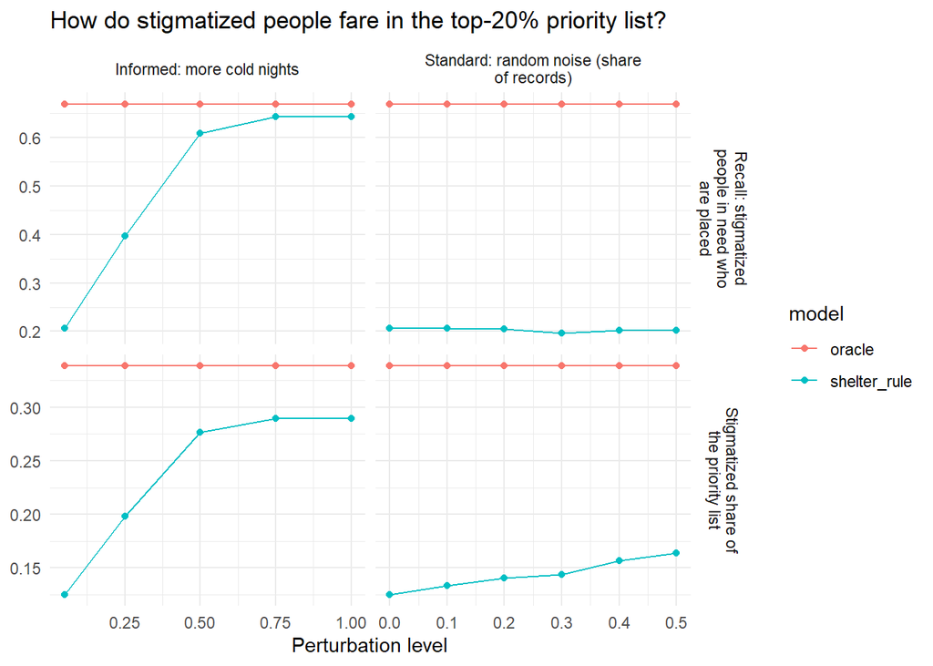

```r
sweeps %>%
  pivot_longer(c(recall_stigmatized, share_stigmatized_placed),
               names_to = "metric", values_to = "y") %>%
  mutate(metric = recode(metric,
           recall_stigmatized       = "Recall: stigmatized people in need who are placed",
           share_stigmatized_placed = "Stigmatized share of the priority list")) %>%
  ggplot(aes(value, y, colour = model)) +
  geom_line() + geom_point() +
  facet_grid(metric ~ perturbation, scales = "free",
             labeller = labeller(.rows = label_wrap_gen(22),
                                 .cols = label_wrap_gen(30))) +
  labs(title = "How do stigmatized people fare in the top-20% priority list?",
       #subtitle = "The flat oracle line shows need is unchanged by both perturbations",
       x = "Perturbation level", y = NULL) +
  theme_minimal()
```

## 6. Perturbation Interval

```r
interval_table <- sweeps %>%
  group_by(perturbation, model) %>%
  arrange(value, .by_group = TRUE) %>%
  summarise(
    level_from        = first(value),
    level_to          = last(value),
    recall_stig_from  = first(recall_stigmatized),
    recall_stig_to    = last(recall_stigmatized),
    recall_non_from   = first(recall_non),
    recall_non_to     = last(recall_non),
    gap_from          = first(gap),
    gap_to            = last(gap),
    list_share_from   = first(share_stigmatized_placed),
    list_share_to     = last(share_stigmatized_placed),
    .groups = "drop"
  ) %>%
  mutate(
    level_means = if_else(grepl("Informed", perturbation),
                          "share of cold nights",
                          "share of shelter records replaced by another person's"),
    change_recall_stig = recall_stig_to - recall_stig_from,
    change_recall_non  = recall_non_to  - recall_non_from,
    change_gap         = gap_to - gap_from
  ) %>%
  relocate(level_means, .after = perturbation) %>%
  mutate(across(where(is.numeric), ~ round(.x, 3)))

# Compact view: how much does each metric move across the interval?
interval_table %>%
  select(perturbation, model, level_from, level_to,
         change_recall_stig, change_recall_non, change_gap) %>%
  knitr::kable(caption = "Change in each metric across the perturbation interval")
```

Change in each metric across the perturbation interval

| perturbation | model | level_from | level_to | change_recall_stig | change_recall_non | change_gap |
| --- | --- | --- | --- | --- | --- | --- |
| Informed: more cold nights | oracle | 0.05 | 1.0 | 0.000 | 0.000 | 0.000 |
| Informed: more cold nights | shelter_rule | 0.05 | 1.0 | 0.437 | -0.020 | 0.458 |
| Standard: random noise (share of records) | oracle | 0.00 | 0.5 | 0.000 | 0.000 | 0.000 |
| Standard: random noise (share of records) | shelter_rule | 0.00 | 0.5 | -0.004 | -0.201 | 0.198 |

```r
# Full view: values at both ends of the interval
interval_table %>%
  select(perturbation, model, level_from, level_to,
         recall_stig_from, recall_stig_to,
         recall_non_from,  recall_non_to,
         gap_from, gap_to) %>%
  knitr::kable(caption = "Metric values at the start and end of each interval")
```

Metric values at the start and end of each interval

| perturbation | model | level_from | level_to | recall_stig_from | recall_stig_to | recall_non_from | recall_non_to | gap_from | gap_to |
| --- | --- | --- | --- | --- | --- | --- | --- | --- | --- |
| Informed: more cold nights | oracle | 0.05 | 1.0 | 0.669 | 0.669 | 0.565 | 0.565 | 0.104 | 0.104 |
| Informed: more cold nights | shelter_rule | 0.05 | 1.0 | 0.206 | 0.643 | 0.591 | 0.571 | -0.385 | 0.073 |
| Standard: random noise (share of records) | oracle | 0.00 | 0.5 | 0.669 | 0.669 | 0.565 | 0.565 | 0.104 | 0.104 |
| Standard: random noise (share of records) | shelter_rule | 0.00 | 0.5 | 0.206 | 0.202 | 0.591 | 0.390 | -0.385 | -0.187 |

```r
# Share of true need that is stigmatized (the same in every scenario)
unique(round(sweeps$share_stigmatized_need, 2))
```

```
## [1] 0.32
```